# chess

##### Model

**Output**: a logistic regression model and a linear regression model.

The logistic regression model has to be able to output 3 different results, from Win, Draw, or Loss, so I used a multinomial logistic regression model for this. Therefore, the random guess has now a 33% chance of being correct instead of 50% correct.

The linear regression model outputs the expected PPG (points per game).

One hot encoding was used to transform categorical variables into numerical ones, and the train-test split used was 80-20, although the train and test accuracy were very similar for any values used from a 65-35 split to a 90-10 split.

```
USER DATA FIRST, MODEL_DF SECOND
```

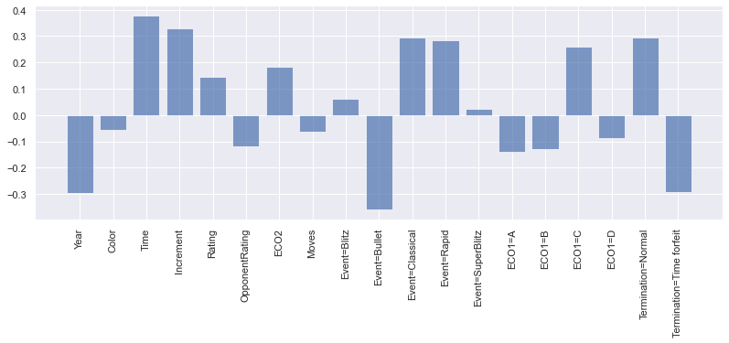

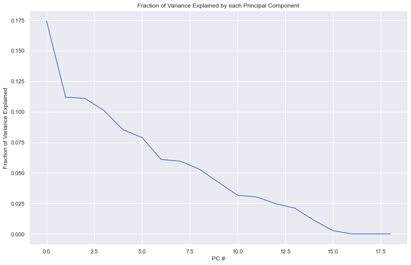

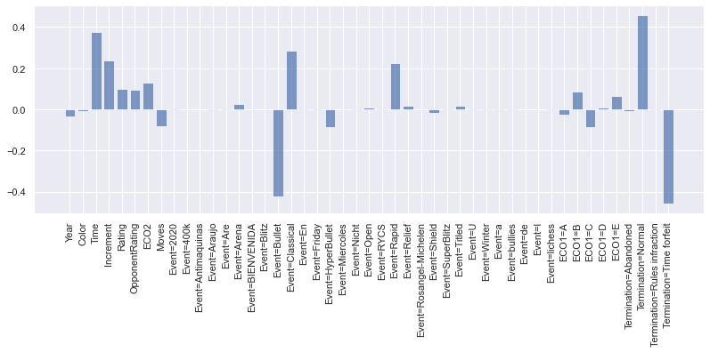

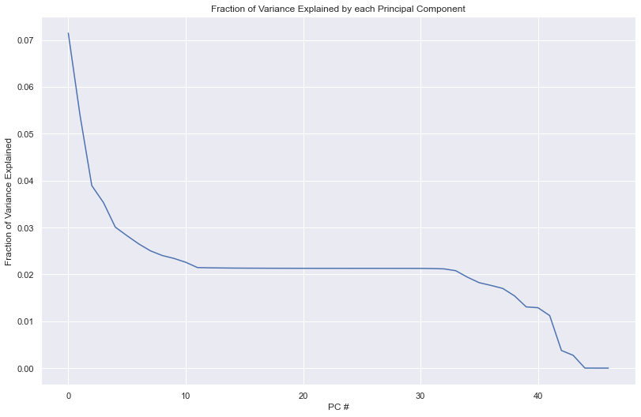

```python
def ohe(df, colname):
    vec = DictVectorizer()
    vec.fit(df[[colname]].to_dict(orient='records'))
    col_data = vec.transform(df[[colname]].to_dict(orient='records')).toarray()
    col_unique = vec.get_feature_names()
    col_ohe = pd.DataFrame(col_data, columns=col_unique)
    df = pd.concat([df, col_ohe], axis=1)
    #df = df.drop(columns=col_unique[0])
    return df

def unique_names(df, colname):
    vec = DictVectorizer()
    vec.fit(df[[colname]].to_dict(orient='records'))
    col_data = vec.transform(df[[colname]].to_dict(orient='records')).toarray()
    col_unique = vec.get_feature_names()
    return col_unique


def df_transformation(df, cols):
    data = df[cols]

    data = data.replace("Black", 0).replace("White", 1)
    data = ohe(data, "Event").drop("Event", axis=1)
    data = ohe(data, "ECO1").drop("ECO1", axis=1)
    data = ohe(data, "Termination").drop("Termination", axis=1)

    pca(data, cols)

    data["Result"] = df["Result"]
    return data


def pca(df, cols):

    # Center data
    df_mean = df.mean(axis=0)
    df_centered = df - df_mean


    # Scale - each col has unit variance
    df_centered_scaled = df_centered / np.sqrt(np.var(df_centered))

    # for the case where all values are 0, SVD doesn't converge
    df_centered_scaled = df_centered_scaled.fillna(0)

    # Break into components
    #df_centered_scaled.dropna(inplace=True)
    u, s, vt = np.linalg.svd(df_centered_scaled, full_matrices=False)

    v = vt.T
    P = df_centered @ v

    plt.figure(figsize=(12, 4))
    plt.bar(df.columns, vt[0, :], alpha=0.7)
    plt.xticks(df.columns, rotation=90)
    plt.show()


    # Scree plot
    plt.plot(s**2 / sum(s**2));
    #plt.xticks([1, 2, 3], [1, 2, 3]);
    plt.xlabel('PC #');
    plt.ylabel('Fraction of Variance Explained');
    plt.title('Fraction of Variance Explained by each Principal Component')

    return P

print("USER DATA FIRST, MODEL_DF SECOND ")
print()
log_df = df_transformation(df, ["Year", "Color", "Time", "Increment", "Event", "Rating", "OpponentRating", "ECO1", "ECO2", "Moves", "Termination"])


model_df_load = pd.read_csv("model_df.csv")
model_df = df_transformation(model_df_load, ["Year", "Color", "Time", "Increment", "Event", "Rating", "OpponentRating", "ECO1", "ECO2", "Moves", "Termination"])
```

```python
def rmse(actual, predicted):
    return np.sqrt(np.sum((actual - predicted)**2) / len(actual))


def model(data, prnt, option, df="", events="", eco1="", self=False):

    data["Result_numeric"] = data["Result"]
    di = {0.0: "Loss", 0.5: "Draw", 1.0: "Win"}
    data = data.replace({"Result":di})

    test_size = 0.2
    train, test = train_test_split(data, test_size=test_size,
                                  #random_state=40
                                 )

    # Logistic Regression
    X_train_log = process_data(train, option, events, eco1, self)
    y_train_log = train["Result"]

    model = LogisticRegression(multi_class='multinomial',solver ='newton-cg', max_iter = len(X_train_log))
    model.fit(X_train_log, y_train_log)


    training_score_log = model.score(X_train_log, y_train_log)

    X_test_log = process_data(test, option, events, eco1, self)
    y_test_log = test["Result"]

    test_score_log = model.score(X_test_log, y_test_log)


    #df["Result_numeric"] = df["Result"]
    #X_self_log = process_data(df, option, events)
    #y_self_log = df["Result"]
    #self_score_log = model.score(X_self_log, y_self_log)



    # Linear Regression
    X_train_lin = X_train_log
    y_train_lin = train["Result_numeric"]
    X_test_lin = X_test_log
    y_test_lin = test["Result_numeric"]

    model_ln = lm.LinearRegression(fit_intercept=True)
    model_ln.fit(X_train_lin, y_train_lin)
    y_predicted_train_lin = model_ln.predict(X_train_lin)
    y_predicted_test_lin = model_ln.predict(X_test_lin)


    training_rmse = rmse(y_predicted_train_lin, y_train_lin)

    test_rmse = rmse(y_predicted_test_lin, y_test_lin)

    if (prnt == True):
        print("Training set size: " + str(len(train)))
        print("Test set size: " + str(len(test)))
        print()
        print("Logistic")
        print("Training accuracy: " + str(training_score_log))
        print("Test accuracy: " + str(test_score_log))
        #if (df != ""):
            #print("Self accuracy: " + str(self_score_log))
        print()
        #print("Linear")
        #print("Training RMSE: " + str(training_rmse))
        #print("Test RMSE: " + str(test_rmse))

    #return model_ln.predict([[1,30,0,1387,1862,0,1,0,0,0]])
    #return y_predicted_train_lin
    return model, model_ln

def process_data(data, option, events, eco1, self):


    # Drops
    filter_eco = [col for col in data if col.startswith("ECO1")]
    if (option < 1):
        for i in filter_eco:
            data = data.drop(i, axis=1)
    elif (self == False):
        for i in filter_eco:
            if i not in eco1:
                data = data.drop(i, axis=1)
    data = data.drop("ECO2", axis=1)


    filter_ter = [col for col in data if col.startswith("Termination")]
    for i in filter_ter:
        data = data.drop(i, axis=1)


    # Events
    if (self == False):
        filter_eve = [col for col in data if col.startswith("Event=")]
        for i in filter_eve:
            if i not in events:
                data = data.drop(i, axis=1)


    data = data.drop(["Moves", "Year", "Result", "Result_numeric"], axis=1)

    if (self == False):
        data = data.drop(["Time", "Increment"], axis=1)
    else:
        data = data.drop(["Rating"], axis=1)

    return data
```

### 9.1 Model 1 : Predictor using model_df

This model uses model_df as training dataset for the model. model_df contains over 49,000 games, with at least 5000 in each of the four game modes. It also spans a rating range of around 1000 to 3000, which I tried to balance evenly for each of the four modes.

**Inputs**: The user enters the side a user plays on, the user's rating, the opponent's rating and the game type.

```python
"""
color: enter "White" or "Black"
rating, opponentRating
event: enter "Blitz", "Bullet", "Classical", "Rapid", or anything else that showed up in "Event" for the PGN file.
"""

side = "Black"
rating = 1980
opponentrating = 1960
event = "Rapid"



standard = []
uni = unique_names(df, "Event")
allowed_uni = ["Event=Bullet", "Event=Blitz", "Event=Rapid", "Event=Classical"]
for i in uni:
    if i in allowed_uni:
        standard.append(i)
event_list = [int(("Event=" + event) == i) for i in standard]


model_1, model_2 = model(model_df, True, 0, df, standard)

if (side == "White"):
    side = 1
else:
    side = 0


concat_list = [side,  rating, opponentrating] + event_list


print(color.YELLOW + "PREDICTED RESULT: " + color.PURPLE + model_1.predict([concat_list])[0])
print(color.YELLOW + "PREDICTED PPG:    " + color.PURPLE + str(round(model_2.predict([concat_list])[0], 4)) + color.END)
```

```
Training set size: 39264
Test set size: 9816

Logistic
Training accuracy: 0.6325641809290954
Test accuracy: 0.631519967400163

PREDICTED RESULT: Win
PREDICTED PPG:    0.5173
```

### 9.2 Model 2 : Predictor without game knowledge

This model uses the user's own games to make a prediction.

**Inputs**: The user enters the side a user plays on, the time control, the opponent's rating and the game type.

```python
"""
color: enter "White" or "Black"
time, increment = time control, ex. 10+5 (set to 10 and 5, for 10 minutes and 5 second increment)
opponentRating
event: enter "Blitz", "Bullet", "Classical", "Rapid", or anything else that showed up in "Event" for the PGN file.
"""

side = "White"
time = 5
increment = 3
opponentrating = 1300

event = "Blitz"



model_1, model_2 = model(log_df, True, 0, self=True)

if (side == "White"):
    side = 1
else:
    side = 0

time = time * 60

uni = unique_names(df, "Event")
event_list = [int(("Event=" + event) == i) for i in uni]

concat_list = [side, time, increment, opponentrating] + event_list


print(color.YELLOW + "PREDICTED RESULT: " + color.PURPLE + model_1.predict([concat_list])[0])
print(color.YELLOW + "PREDICTED PPG:    " + color.PURPLE + str(round(model_2.predict([concat_list])[0], 4)) + color.END)
```

```
Training set size: 456
Test set size: 114

Logistic
Training accuracy: 0.75
Test accuracy: 0.7017543859649122

PREDICTED RESULT: Loss
PREDICTED PPG:    0.3259
```

### 9.3 Model 3 : Predictor with opening knowledge

This model uses the user's own games to make a prediction.

**Inputs**: The user enters the side a user plays on, the time control, the opponent's rating, the game type, and also the ECO letter code.

```python
"""
color: enter "White" or "Black"
time, increment = time control, ex. 10+5 (set to 10 and 5, for 10 minutes and 5 second increment)
opponentRating
eco1 = letter of ECO opening (ex. "C" from C45)
event: enter "Blitz", "Bullet", "Classical", "Rapid", or anything else that showed up in "Event" for the PGN file.
"""

side = "White"
time = 1
increment = 0
opponentrating = 1100
eco1 = "C"
event = "Bullet"



model_1, model_2 = model(log_df, True, 1, self=True)

if (side == "White"):
    side = 1
else:
    side = 0

time = time * 60

uni = unique_names(df, "Event")
event_list = [int(("Event=" + event) == i) for i in uni]

eco = unique_names(df, "ECO1")
eco_list = [int(("ECO1=" + eco1) == i) for i in eco]

concat_list = [side, time, increment, opponentrating] + event_list + eco_list


print(color.YELLOW + "PREDICTED RESULT: " + color.PURPLE + model_1.predict([concat_list])[0])
print(color.YELLOW + "PREDICTED PPG:    " + color.PURPLE + str(round(model_2.predict([concat_list])[0], 4)) + color.END)
```

```
Training set size: 456
Test set size: 114

Logistic
Training accuracy: 0.7390350877192983
Test accuracy: 0.7631578947368421

PREDICTED RESULT: Win
PREDICTED PPG:    0.4642
```